# Week 3: Text mining I

SECU0050

Bennett Kleinberg

30 Jan 2020

Data Science for Crime Scientists

## Week 3: Text mining 1

## Today

- text quantification
- numerical representations
- common text metrics

[figure not shown]

## Text is everywhere …

- Practically all websites
- Emails
- Messaging
- Government reports
- Laws
- Police reports
- Uni coursework
- Newspapers

## … and everything is text

- videos –> transcripts
- music –> lyrics
- conversations –> transcripts
- speeches –> transcripts

## Core idea

Text is a unique documentation of human activity.

*We are obsessed with documenting.*

## Text example

How would you analyse the text?

## Example

> All I ever wanted was to love women, and in turn to be loved by them back. Their behavior towards me has only earned my hatred, and rightfully so! I am the true victim in all of this. I am the good guy. Humanity struck at me first by condemning me to experience so much suffering. I didn’t ask for this. I didn’t want this. I didn’t start this war. I wasn’t the one who struck first. But I will finish it by striking back. I will punish everyone. And it will be beautiful. Finally, at long last, I can show the world my true worth.

## Challenge of quantification

- text is not a numerical representation
- compare this to trading data, crime statistics, etc.
- text is just that, “a text”
- but: for quantitative analyses, we need numbers

Text –> numerical representation?

## Features of text data

- meta dimension
- syntactic dimension
- semantic dimension
- text metrics

## Meta dimension

- no. of words
- no. of sentences

## Syntactic dimension

- word frequencies
- verbs, nouns, persons, locations, ..
- structure of a sentence

## Semantic dimension

- sentiment
- psycholinguistic features

## Text metrics

- readability
- lexical diversity

## The `quanteda` package

```r
library(quanteda)
```

- [quanteda: Quantitative Analysis of Textual Data](https://quanteda.io/)
  - documentation
  - tutorials
  - examples

## Levels of text data

- characters `c('h', 'a', 't', 'r', 'e', 'd')`
- words `hatred`
- sentences `I didn’t ask for this.`
- documents: individual text files
- corpora: collection of documents

## Counting meta features in R

| text level | R function |
| --- | --- |
| characters | `nchar()` |
| words | `quanteda::ntoken()` |
| sentences | `quanteda::nsentence()` |

## R examples

```r
#sentences
no_of_sentences = nsentence(er)
no_of_sentences
```

```
## text1
##    13
```

```r
#words 1
no_of_words_1 = ntoken(er)
no_of_words_1
```

```
## text1
##   123
```

```r
#words 2
no_of_words_2 = ntype(er)
no_of_words_2
```

```
## text1
##    72
```

## Type-toke ratio

Note: often used metric for “lexical diversity” is the TTR (type-token ratio).

```r
string_a = "I didn’t ask for this. I didn’t want this."
string_b = "But I will finish it by striking back."
```

**What are the type-token ratios of each string?**

## Type-token ratio

```r
ntype(string_a)/ntoken(string_a)
```

```
##     text1
## 0.6363636
```

```r
ntype(string_b)/ntoken(string_b)
```

```
## text1
##     1
```

## Characters per word

```r
nchar(er)/ntoken(er)
```

```
##    text1
## 4.317073
```

## Words per sentence

```r
ntoken(er)/nsentence(er)
```

```
##    text1
## 9.461538
```

### Text representation

## Aim

- representing a text by its tokens (terms)
- each text consists of a frequency of its tokens

```r
"I think I believe him"
```

## Text representation by hand

1. create a column for each token
2. count the frequency

| text_id | I | think | believe | him |
| --- | --- | --- | --- | --- |
| text1 | 2 | 1 | 1 | 1 |

## Term frequency

- frequency of each token in each document
- represented in a table (matrix)
- tokens are features of a document
- voilá: **Document Feature Matrix (= DFM)**

```r
example_string_tok = tokens("I think I believe him")
```

## DFM in `quanteda`

- from ‘tokens’ object, create a DFM table

```r
dfm(example_string_tok)
```

```
## Document-feature matrix of: 1 document, 4 features (0% sparse).
## 1 x 4 sparse Matrix of class "dfm"
##        features
## docs    i think believe him
##   text1 2     1       1   1
```

## Sparsity

Sparsity = % of zero-cells

- Why is sparsity = 0% here?
- What would you expect if we take additional documents, and why?

## DFM with multiple documents

```r
multiple_docs_tok = tokens(c("I think I believe him", "This is a cool function"))
```

```r
dfm(multiple_docs_tok)
```

```
## Document-feature matrix of: 2 documents, 9 features (50% sparse).
## 2 x 9 sparse Matrix of class "dfm"
##        features
## docs    i think believe him this is a cool function
##   text1 2     1       1   1    0  0 0    0        0
##   text2 0     0       0   0    1  1 1    1        1
```

## DFM with two lone-actors

> All I ever wanted was to love women, and in turn to be loved by them back. Their behavior towards me has only earned my hatred, and rightfully so! I am the true victim in all of this. I am the good guy. Humanity struck at me first by condemning me to experience so much suffering. I didn’t ask for this. I didn’t want this. I didn’t start this war. I wasn’t the one who struck first. But I will finish it by striking back. I will punish everyone. And it will be beautiful. Finally, at long last, I can show the world my true worth.

## DFM with two texts

> The Industrial Revolution and its consequences have been a disaster for the human race. They have greatly increased the life-expectancy of those of us who live in “advanced” countries, but they have destabilized society, have made life unfulfilling, have subjected human beings to indignities, have led to widespread psychological suffering (in the Third World to physical suffering as well) and have inflicted severe damage on the natural world. The continued development of technology will worsen the situation.

## Using the corpus method

- Create a “mini corpus” for convenience
- makes using the quanteda pipeline easier

```r
mini_corpus = corpus(c(er, ub))
summary(mini_corpus)
```

```
## Corpus consisting of 2 documents:
##
##   Text Types Tokens Sentences
##  text1    72    123        13
##  text2    63     88         3
##
## Source: /Users/bennettkleinberg/GitHub/UCL_SECU0050/lectures/week_3/* on x86_64 by bennettkleinberg
## Created: Thu Jan 30 06:38:03 2020
## Notes:
```

## DFM representation

```r
corpus_tokenised = tokens(mini_corpus)
corpus_dfm = dfm(corpus_tokenised)
```

| document | all | i | ever | wanted | was | to | love | women |
| --- | --- | --- | --- | --- | --- | --- | --- | --- |
| text1 | 2 | 10 | 1 | 1 | 1 | 3 | 1 | 1 |
| text2 | 0 | 0 | 0 | 0 | 0 | 3 | 0 | 0 |

| document | am | the | true | victim | of | this | good | guy |
| --- | --- | --- | --- | --- | --- | --- | --- | --- |
| text1 | 2 | 4 | 2 | 1 | 1 | 4 | 1 | 1 |
| text2 | 0 | 7 | 0 | 0 | 3 | 0 | 0 | 0 |

**Is this ideal?**

## What are the most frequent “terms”?

```r
topfeatures(corpus_dfm[1])
```

```
##      .      i      ,    the   this     to    and     by     me didn't
##     12     10      4      4      4      3      3      3      3      3
```

```r
topfeatures(corpus_dfm[2])
```

```
##       the      have         ,        to         .        of       and
##         7         7         4         3         3         3         2
##        in suffering     world
##         2         2         2
```

## [Zipf’s Law](https://www.youtube.com/watch?v=fCn8zs912OE)

[figure not shown]

## Word hierarchies

- some words add more meaning than others
- stopwords = meaningless (?)
- in any case: too frequent words, don’t tell much about the documents
- ideally: we want to get an *importance score* for each word

## Word importance

| document | and | in | turn | be | loved | by |
| --- | --- | --- | --- | --- | --- | --- |
| text1 | 3 | 2 | 1 | 2 | 1 | 3 |
| text2 | 2 | 2 | 0 | 0 | 0 | 0 |

We want to “reward” words that are:

- important locally (for individual documents)
- but not ‘inflated’ globally (for the whole corpus)

## Metric for word importance: term frequency

- $tf(t, d) = \frac{\#_{t,d}}{nwords_d}$ (proportion)
- $tf(t, d)$ = #_(t, d) (count)

## Proportions

| document | and | in | turn | be | loved | by |
| --- | --- | --- | --- | --- | --- | --- |
| text1 | 0.024 | 0.016 | 0.008 | 0.016 | 0.008 | 0.024 |
| text2 | 0.023 | 0.023 | 0.000 | 0.000 | 0.000 | 0.000 |

## Counts

| document | and | in | turn | be | loved | by |
| --- | --- | --- | --- | --- | --- | --- |
| text1 | 3 | 2 | 1 | 2 | 1 | 3 |
| text2 | 2 | 2 | 0 | 0 | 0 | 0 |

## Double-check the formulae

- $tf(t, d) = \frac{\#_{t, d}}{nwords_d}$
- $tf(t, d)$ = #_(t, d)

```r
3/ntoken(mini_corpus[1])
```

```
##      text1
## 0.02439024
```

Term frequency: *reward for words that occur often in a document*

## Problem

Some words just occur a lot anyway (e.g. “stop words”).

Global occurrence: document frequency

|  | x |
| --- | --- |
| and | 2 |
| in | 2 |
| turn | 1 |
| be | 1 |
| loved | 1 |
| by | 1 |

$df(t) =$ # of docs with t

## DF

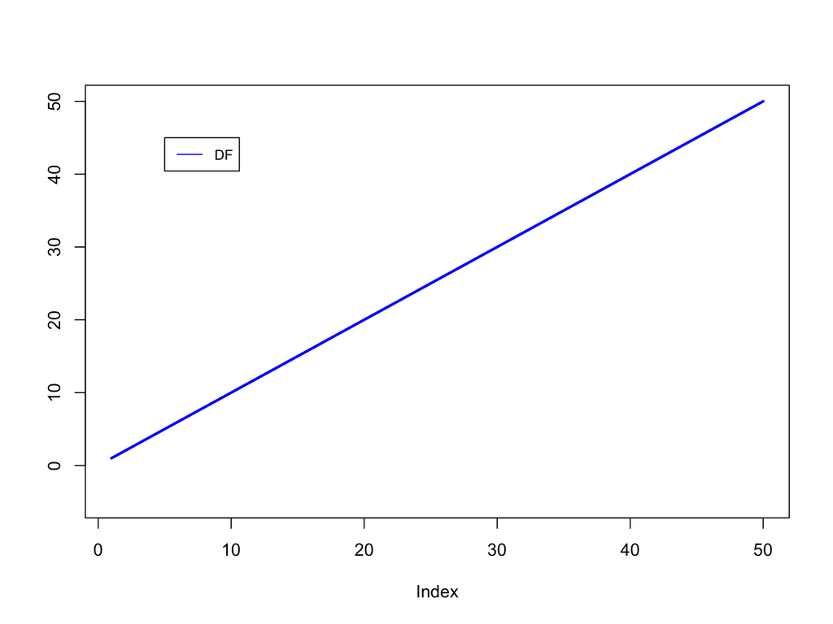

## Correcting for term inflation

- we want: low values for common words
- and: higher values for *important* words

Trick: *inverse* document-frequency

## Inverse DF (IDF)

$idf(t) = \frac{N}{df(t)}$

## IDF

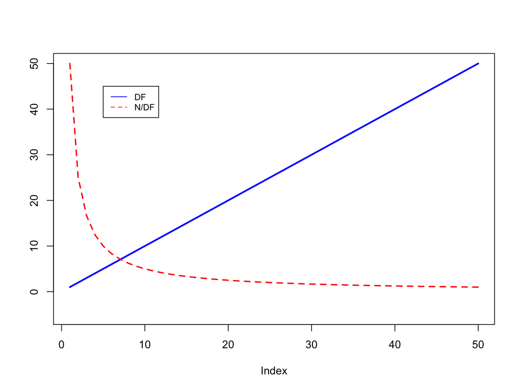

## Problem?

- What happens if $N$ becomes really large?

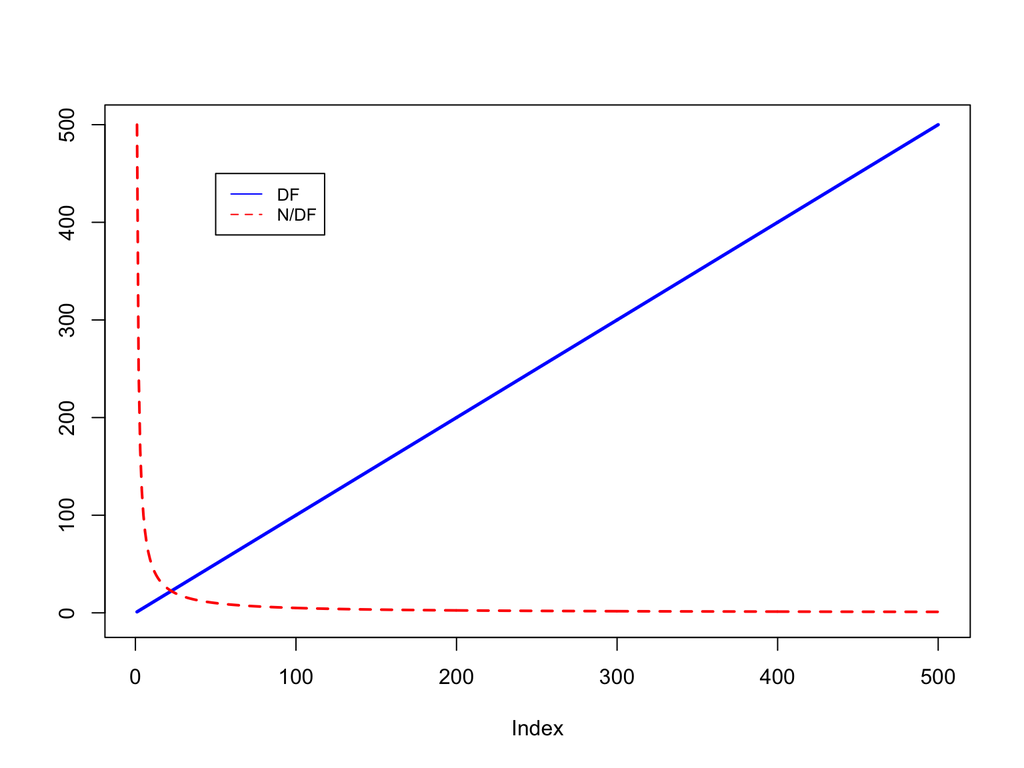

## Log IDF

- to avoid extreme values, we use the logarithm
- simple transformation: $idf(t) = log(\frac{N}{df(t)+1})$

## About logarithms

$log_b(a) = c <=> b^c = a$

“the power to which {base b} would have to be raised to equal a”

$log_2(8) = ?$ –> $2^? = 8$

## Logarithm bases

- natural logarithm: base $e = 2.718281...$
- base 10 logarithm: $log_{10}(x)$

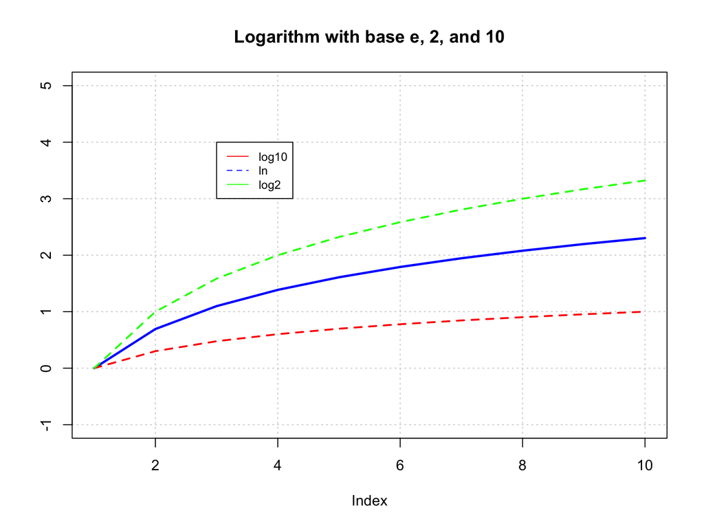

## Log IDF

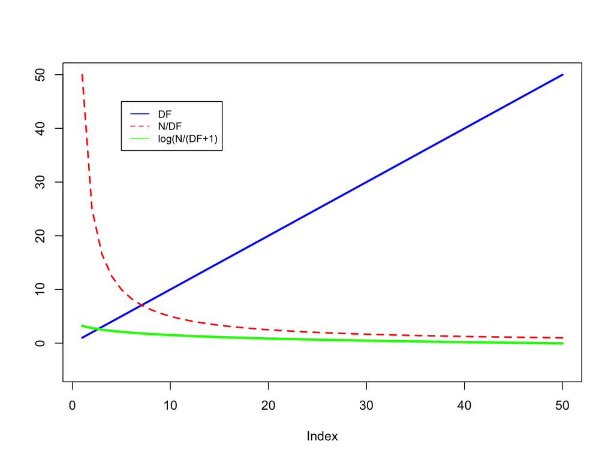

## Combining term frequency and document frequency

1. Local importance (TF)

| document | and | in | turn |
| --- | --- | --- | --- |
| text1 | 3 | 2 | 1 |
| text2 | 2 | 2 | 0 |

2. Correct for global occurrences (DF)

   |  | x |
   | --- | --- |
   | and | -0.1760913 |
   | in | -0.1760913 |
   | turn | 0.0000000 |

## TF/IDF

```r
#text1: "and"
3/-0.1760913

#text2: "and"
2/-0.1760913
```

## TF-IDF

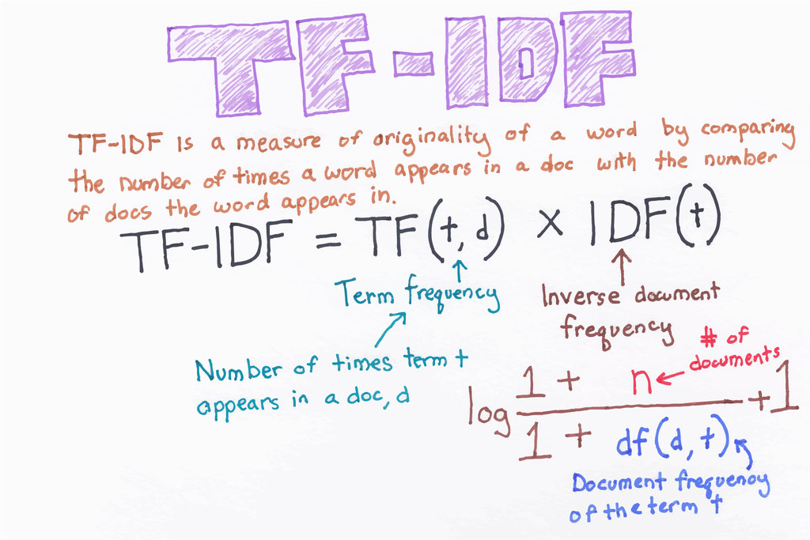

[Img reference](https://chrisalbon.com/machine_learning/preprocessing_text/tf-idf/)

### Working with text as data

## Researcher’s degrees of freedom

- stop word removal
- stemming

## Stopword removal

- We know many words are “low in meaning”
- so-called stop words

| x |
| --- |
| i |
| me |
| my |
| myself |
| we |
| hers |
| herself |
| it |
| its |
| itself |
| they |

## Without stopword removal

| document | all | i | ever | wanted | was | to | love | women |
| --- | --- | --- | --- | --- | --- | --- | --- | --- |
| text1 | 2 | 10 | 1 | 1 | 1 | 3 | 1 | 1 |
| text2 | 0 | 0 | 0 | 0 | 0 | 3 | 0 | 0 |

## With stopword removal

| document | ever | wanted | love | women | , | turn | loved | back |
| --- | --- | --- | --- | --- | --- | --- | --- | --- |
| text1 | 1 | 1 | 1 | 1 | 4 | 1 | 1 | 2 |
| text2 | 0 | 0 | 0 | 0 | 4 | 0 | 0 | 0 |

## Stemming

- some words originate from the same “stem”
- e.g. “love”, “loved”, “loving”, “lovely”
- but you might want to reduce all these to the stem

## Word stems

```r
love_stem = c("love", "loved", "loving", "lovely")
```

| document | love | loved | loving | lovely |
| --- | --- | --- | --- | --- |
| text1 | 1 | 0 | 0 | 0 |
| text2 | 0 | 1 | 0 | 0 |
| text3 | 0 | 0 | 1 | 0 |
| text4 | 0 | 0 | 0 | 1 |

## After stemming

| document | love |
| --- | --- |
| text1 | 1 |
| text2 | 1 |
| text3 | 1 |
| text4 | 1 |

## Our mini corpus

Incl. stop words and without stemming:

| document | all | i | ever | wanted | was | to | love | women |
| --- | --- | --- | --- | --- | --- | --- | --- | --- |
| text1 | 2 | 10 | 1 | 1 | 1 | 3 | 1 | 1 |
| text2 | 0 | 0 | 0 | 0 | 0 | 3 | 0 | 0 |

## … to

Without stop words and stemmed:

| document | ever | want | love | women | , | turn | back | . |
| --- | --- | --- | --- | --- | --- | --- | --- | --- |
| text1 | 1 | 2 | 2 | 1 | 4 | 1 | 2 | 12 |
| text2 | 0 | 0 | 0 | 0 | 4 | 0 | 0 | 3 |

## Text metrics

- lexical diversity (= TTR)
- readability

## Readability

- ease of understanding for the reader
- readability vs legibility
- here: focus on language

## Readability aspects

- No. of words
- No. of characters
- No. of *difficult* words
- punctuation
- number of syllables

## Readability metrics

- [Flesch Reading Ease score](https://web.archive.org/web/20160712094308/http://www.mang.canterbury.ac.nz/writing_guide/writing/flesch.shtml)
- [Coleman–Liau index](https://psycnet.apa.org/record/1975-22007-001)
- [Automated readability index (ARI)](https://apps.dtic.mil/dtic/tr/fulltext/u2/667273.pdf)

## Flesch Reading Ease score

Requires:

- No. of words
- No. of sentences
- No. of syllables

$FRE = 206.835 - 1.015*(\frac{nwords}{nsentences}) - 84.6*(\frac{nsyllables}{nwords})$

## Score interpretation

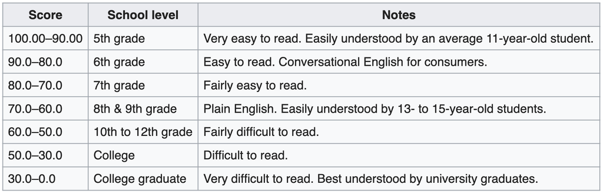

## FRE in R

```r
n_words = ntoken(mini_corpus[1])
n_sentences = nsentence(mini_corpus[1])
n_syllables = nsyllable(mini_corpus[1])
```

## Custom function

```r
fre_score = function(input_text){
  n_words = ntoken(input_text)
  n_sentences = nsentence(input_text)
  n_syllables = nsyllable(input_text)
  fre = 206.835 - 1.015*(n_words/n_sentences) - 84.6*(n_syllables/n_words)
  return(unname(fre))
}
```

## Calculating the FRE

```r
fre_score(mini_corpus[1])
```

```
## [1] 100.2511
```

```r
fre_score(mini_corpus[2])
```

```
## [1] 26.12758
```

## Coleman-Liau index

$CLI = 0.0588*\frac{nchar}{nwords}*100 - 0.296*\frac{nsentences}{nwords}*100 - 15.8$

Outcome score $\approx$ US grade-level.

## CLI function

```r
cli_score = function(input_text){
  n_words = ntoken(input_text)
  n_sentences = nsentence(input_text)
  n_characters = nchar(input_text)
  cli = 0.0588*(n_characters/n_words)*100 - 0.296*(n_sentences/n_words)*100 - 15.8
  return(unname(cli))
}
```

```r
cli_score(mini_corpus[1])
```

```
## [1] 6.455935
```

```r
cli_score(mini_corpus[2])
```

```
## [1] 17.46864
```

## Considerations with text data

- a lot of assumptions
- text == behaviour?
- produced text == displayed text?
- many decisions in your hand
  - stemming
  - stop words
  - custom dictionary

## What’s next?

- Today’s tutorial: analysing speeches by US presidents, examining UK rap lyrics
- Homework: quanteda practice, text preprocessing

Next week: Text Mining 2